# EpiModel

Edyniesky

3 de junio de 2016

## Modelos determinista compartimentales (MCD)

Modelos compartimentales deterministas resolver ecuaciones diferenciales que representan los sistemas analíticos epidémicas en tiempo continuo.

# Modelo **SI**

\begin{align} \frac{dS}{dt} &= -\lambda S \notag \\[4pt] \frac{dI}{dt} &= \lambda S \end{align}

Donde $\lambda$ es la fuerza con la que acontece la infección y esta representada por $\frac{\beta c I}{N}$, $\beta$ es la probabilidad de transmisión por contacto,*c* es la tasa de contacto por persona por unidad de tiempo, *I* es el número de infectados en el tiempo *t* y *N* es el tamaño de la poblacion en el tiempo *t*

La fuerza de la infección e multiplicada por el estado en que se emcuemtra **S** (susceptibles).

-Para simular modelos deterministas **EpiModel** utiliza la función:

–**dcm**

Antes de ejecutar el modelo, es necesario para parametrizarlo.

En **param.dcm**, se introducen los parámetros del modelo epidémico. El argumento **inf.prob** establece la probabilidad de transmisión por acto, y **act.rate** establece los actos por persona por unidad de tiempo. La función **init.dcm** recoge las condiciones iniciales para el modelo, y dado que esten en el modelo SI es necesario especificar el número inicial **susceptibles** e **infectados** en $t_1$.

El control.dcm finalmente recoge otros controles de modelo estructural como el **tipo de modelo** y el **número de pasos de la simulación**.

```r
param <- param.dcm(inf.prob = 0.2, act.rate = 0.25)
init <- init.dcm(s.num = 500, i.num = 1)
control <- control.dcm(type = "SI", nsteps = 500)
```

```r
mod <- dcm(param, init, control)

print(mod)
```

```
## EpiModel Simulation
## =======================
## Model class: dcm
##
## Simulation Summary
## -----------------------
## Model type: SI
## No. runs: 1
## No. time steps: 500
## No. groups: 1
##
## Model Parameters
## -----------------------
## inf.prob = 0.2
## act.rate = 0.25
##
## Model Output
## -----------------------
## Compartments: s.num i.num num
## Flows: si.flow
```

— *si.flow* es la poblacion que se mueve de *S* para *I*.

Em terminos epidemiológicos *i.num* y *si.flow* representan la prevalencia y la incidencia.

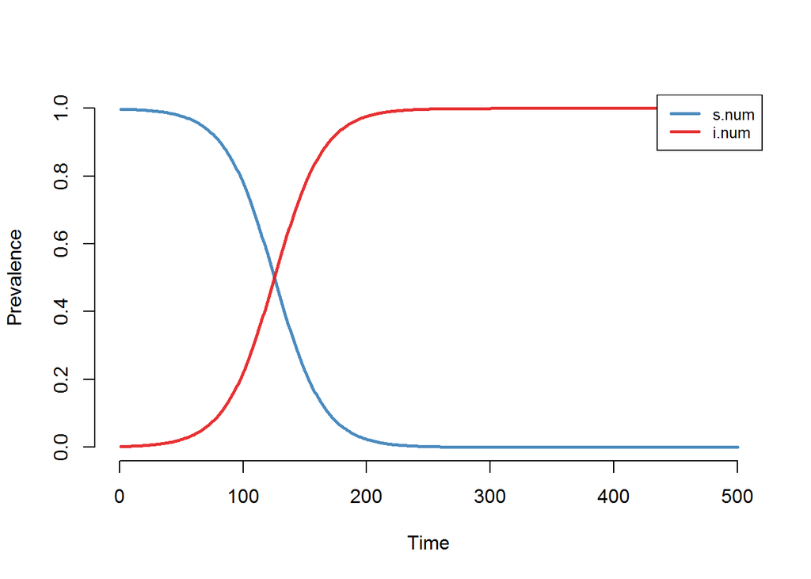

```r
plot(mod)
```

```r
summary(mod, at = 150)
```

```
## EpiModel Summary
## =======================
## Model class: dcm
##
## Simulation Summary
## -----------------------
## Model type: SI
## No. runs: 1
## No. time steps:
## No. groups: 1
##
## Model Statistics
## ------------------------------
## Time: 150     Run: 1
## ------------------------------
##                 n    pct
## Suscept.  112.845  0.225
## Infect.   388.155  0.775
## Total     501.000  1.000
## S -> I      4.311     NA
## ------------------------------
```